# Project

## 6. Data Visualization and Insights:

The goal of these scatter plots and column charts is to visualize the distribution of customers in terms of their Recency, Frequency, and Monetary values, and to see how these customers are grouped into different clusters based on the 'prediction' column.

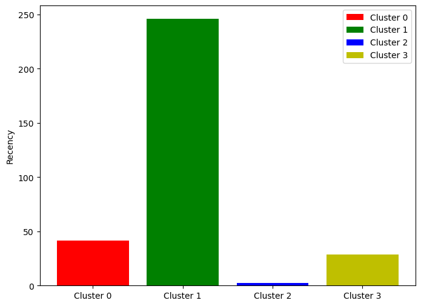

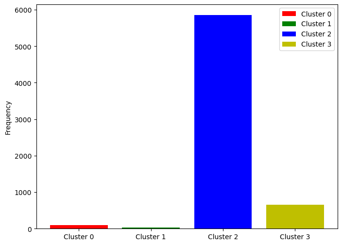

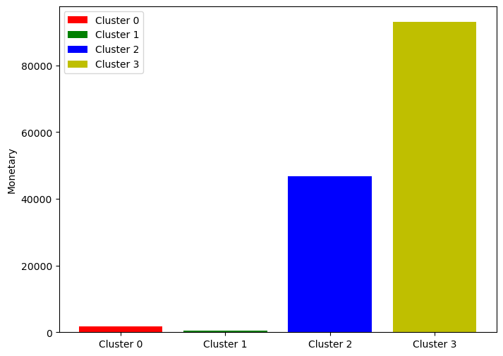

```python
#To see the results more clearly, we will use column charts:
#The results from these charts will help us get and show insights below:
import matplotlib.pyplot as plt

preds_data = preds.select('CustomerID', 'Recency', 'Frequency', 'Monetary', 'prediction').toPandas()

colors = ['r', 'g', 'b', 'y']

attributes = ['Recency', 'Frequency', 'Monetary']

#The code you provided generates bar plots to visualize the average values of specific attributes for each cluster.
#Each bar plot represents the mean value of a particular attribute (e.g., Recency, Frequency, Monetary) for the four clusters.
for attribute in attributes:
    plt.figure(figsize=(8, 6))
    for cluster in range(4):
        cluster_data = preds_data[preds_data['prediction'] == cluster]
        cluster_attribute_mean = cluster_data[attribute].mean()
        plt.bar(cluster, cluster_attribute_mean, color=colors[cluster], label=f'Cluster {cluster}')
    plt.ylabel(attribute)
    plt.xticks(range(4), ['Cluster 0', 'Cluster 1', 'Cluster 2', 'Cluster 3'])
    plt.legend()
    plt.show()
```

Some insights about these specific clusters:

After doing the RFM Analysis, we can propose an allocation of cost percentages plan to each cluster. For this example, let's assume a total cost allocation of 100%.

- Cluster 0 (Medium Recency, Low Frequency, Low Monetary Value): Allocate 5-10% of cost to this cluster

While these customers may not contribute significantly to revenue, a small portion of the budget is allocated to re-engage them and prevent further attrition

Activities for this cluster: Focus on improving customer engagement and increasing the average order value. Implement strategies to encourage repeat purchases, such as offering loyalty programs, personalized recommendations, or targeted promotions based on past purchase behavior. Enhance the user experience on the website to make it easier for customers to find products and complete purchases. Consider bundling products or offering discounts for bulk purchases to incentivize higher spending

- Cluster 1 (High Recency, Very Low Frequency, Very Low Monetary Value): Allocate 10-15% of cost to this cluster.

Since these customers spend relatively little and infrequently, a smaller portion of the budget is allocated to encourage them to increase their spending.

- Cluster 2 (Low Recency, High Frequency, Medium Monetary Value): Allocate 30-35% of cost to this cluster . These engaged customers represent potential for increased spending, so a moderate portion of the budget is allocated to maintain their loyalty and encourage further purchases

- Cluster 3 (Medium Recency, Medium Frequency, High Monetary Value): Allocate 35-40% of cost to this cluster

These high-value customers represent a significant portion of revenue, so a larger portion of the budget is allocated to maintain their loyalty and encourage continued high-value transactions

These percentages are just rough estimates and can vary based on factors such as the size of each cluster, the potential for growth, and the company's overall revenue goal

Activities for this cluster: Prioritize customer satisfaction and retention strategies to capitalize on the high monetary value of this segment. Offer personalized services or incentives to enhance their loyalty and encourage repeat purchases, such as dedicated account managers, priority support, or exclusive access to premium content or events. Collect feedback regularly to understand their evolving needs and preferences and adapt your offerings accordingly. Explore opportunities for upselling or cross-selling to maximize the lifetime value of these customers, such as recommending complementary products or services based on their past purchases.

# III. Conclusion

By leveraging these insights and the specific recommendations above, businesses can build targeted marketing campaigns, personalized product recommendations, and optimized pricing strategies, ultimately leading to enhanced customer satisfaction, increased sales, and improved competitiveness. Therefore, the integration of RFM techniques and clustering algorithms has proven to be instrumental in enabling businesses to develop highly effective and tailored strategies, driving sustainable growth and success in today's dynamic business landscape. We hope that the above experimental results provide businesses with further ideas and suggestions for developing their businesses.